# Caracal Distribution

Grethen de Waal

2026-03-05

## Introduction

The urban caracal experiences significant anthropogenic challenges that impact their territories, foraging and lifespans. Major roads and fenced green areas particularly limit their ranges. However, some caracals choose to forage in disturbed areas as novel resources can be found there.

Distribution data were taken from two sources: iNaturalist, a free citizen science platform where users upload sightings of plants, animals and fungi; and Movebank, an online databse for animal tracking and bio-logging data.

The purpose of this project was to code maps that show the distribution of reported iNaturalist sightings and the GPS readings of a single tagged caracal recorded in the Movebank dataset.

## Methods and Code

### iNaturalist sightings

Read data into R using `rinat`:

```r
library("rinat")       #  Barve & Hart (2025)

inat_obs_raw <- get_inat_obs(taxon_name = "Caracal caracal",
                   bounds = c(-35, 18, -33.5, 18.5),
                   quality = "research",
                   maxresults = 500)
```

```r
library(tidyverse)       # Wickham et al. (2019)
inat_obs <- inat_obs_raw %>%
  filter(coordinates_obscured == "false")
```

The data frame was then converted to spatial data:

```r
library(sf)            # Pebesma & Bivand (2023), Pebesma (2018)
inat_sf <- st_as_sf(
  inat_obs,
  coords = c("longitude", "latitude"),
  crs = 4326)
```

The data were plotted onto an interactive map:

```r
library(leaflet)     # Cheng et al. (2025)
library(mapview)     # Appelhans et al (2025)
library(leafpop)     # Appelhans & Detsch (2021)
library(move2)       # Kranstauber et al. (2024)

sighting <- inat_sf %>%
  mutate('🔗' = paste("<b><a href='", url, "'>Link to iNat observation</a></b>"),
         '📷' = paste("<img src ='", image_url , "' height='128'>")) %>%
  rename('👤' = "user_login", captive = captive_cultivated)

mapview(sighting,
        popup = popupTable(sighting,
                           zcol = c("👤", "🔗", "📷")))
```

[interactive chart not shown]

**Figure 1** shows caracal sightings reported on [iNaturalist](https://www.inaturalist.org/observations?place_id=123155&subview=map&taxon_id=42042) in the Cape Peninsula.

The map is interactive. Hovering over an observation (“sighting”) displays a number. Clicking on the number displays the user who submitted the sighting, the URL to the iNaturalist entry and the photo that goes with it.

### Movebank data

The Movebank database where [Urban Caracal Project](https://www.urbancaracal.org/) (UCP) stores its distribution data has over 57,000 observations and is more than 10MB big, so a single cat was selected to map. The data is from a study by Serieys and Bishop in 2025.

The Movebank data are under a Creative Commons Attribution-NonCommercial (CC BY-NC) licence.

Read data into R and convert to spatial data:

```r
jasper_movebank <- read.csv2("data/jasper_movebank.csv")

jasper_sf <- jasper_movebank %>%
  filter(!is.na(location_long)) %>%          # Remove missing GPS points or it won't run
  st_as_sf(coords = c("location_long", "location_lat"), crs = 4326)
```

Plot the Movebank data:

```r
library(ggspatial)       # Dunnington (2025)

jasper_map <- ggplot() +
  annotation_map_tile(type = "osm", progress = "none") +
  geom_sf(data = jasper_sf)

jasper_map <- leaflet() %>%
  addTiles(group = "Default") %>%
  addCircleMarkers(data = jasper_sf,
                   radius = 0.2,
                   color = "orange")

jasper_map
```

[interactive chart not shown]

**Figure 2** shows the sightings of one of the tagged UCP cats called Jasper. This map is interactive with a zoom function.

### Combined map

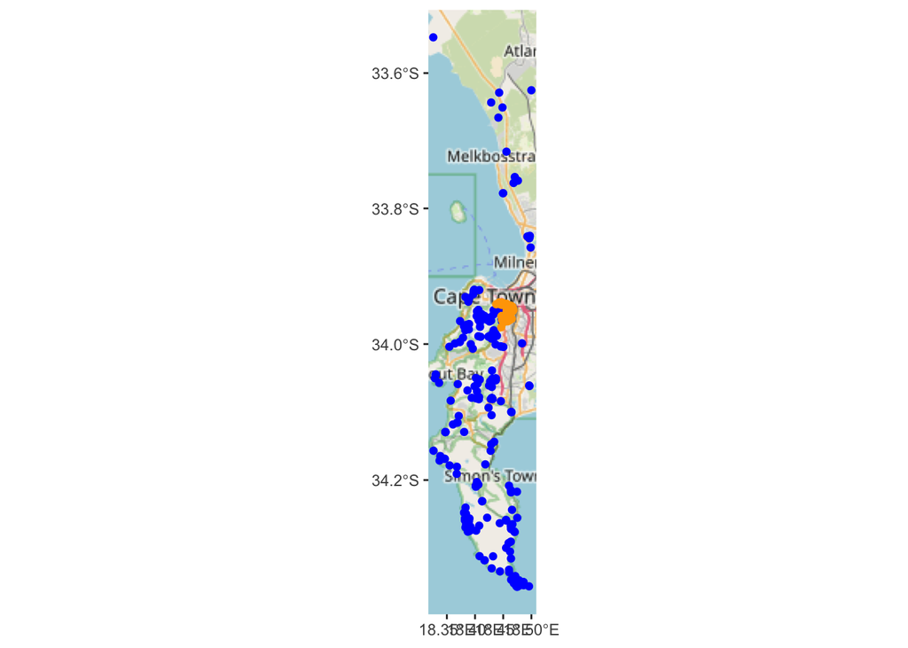

```r
library(rosm)            # Dunnington (2026)

caracal_map <- ggplot() +
  annotation_map_tile(type = "osm", progress = "none") +
  geom_sf(data = inat_sf, color = "blue") +
  geom_sf(data = jasper_sf, color = "orange")

caracal_map
```

**Figure 3** shows Movebank’s data on Jasper’s movements (orange) and the iNaturalist sightings (blue) on a static map of the Cape Peninsula.

## References

- Appelhans T, Detsch F (2021). *leafpop: Include Tables, Images and Graphs in Leaflet Pop-Ups*. doi:10.32614/CRAN.package.leafpop https://doi.org/10.32614/CRAN.package.leafpop, R package version 0.1.0, https://CRAN.R-project.org/package=leafpop.
- Appelhans T, Detsch F, Reudenbach C, Woellauer S (2025). *mapview: Interactive Viewing of Spatial Data in R*. doi:10.32614/CRAN.package.mapview https://doi.org/10.32614/CRAN.package.mapview, R package version 2.11.4, https://CRAN.R-project.org/package=mapview.
- Barve V, Hart E (2025). *rinat: Access ‘iNaturalist’ Data Through APIs*. R package version 0.1.10.9000, commit 44c9f1c892765e40948b2a286a53f302328ccf03, https://github.com/ropensci/rinat.
- Cheng J, Schloerke B, Karambelkar B, Xie Y, Aden-Buie G (2025). *leaflet: Create Interactive Web Maps with the JavaScript ‘Leaflet’ Library*. doi:10.32614/CRAN.package.leaflet https://doi.org/10.32614/CRAN.package.leaflet, R package version 2.2.3, https://CRAN.R-project.org/package=leaflet.
- Dunnington, D (2025). *ggspatial: Spatial Data Framework for ggplot2*. doi:10.32614/CRAN.package.ggspatial https://doi.org/10.32614/CRAN.package.ggspatial, R package version 1.1.10, https://CRAN.R-project.org/package=ggspatial.
- Dunnington, D (2026). *rosm: Plot Raster Map Tiles from Open Street Map and Other Sources*. doi:10.32614/CRAN.package.rosm https://doi.org/10.32614/CRAN.package.rosm, R package version 0.3.1, https://CRAN.R-project.org/package=rosm.
- iNaturalist community. Observations of Caracal caracal from Cape Peninsula, South Africa. Exported from https://www.inaturalist.org on 1 March 2026
- Kranstauber B, Safi K, Scharf AK (2024). “move2: R package for processing movement data.” *Methods in Ecology and Evolution*. doi:10.1111/2041-210X.14383 https://doi.org/10.1111/2041-210X.14383, https://doi.org/10.1111/2041-210X.14383.
- Pebesma, E, 2018. Simple Features for R: Standardized Support for Spatial Vector Data. The R Journal 10 (1),439-446, https://doi.org/10.32614/RJ-2018-009
- Pebesma, E, & Bivand, R (2023). Spatial Data Science: With Applications in R. Chapman and Hall/CRC. https://doi.org/10.1201/9780429459016
- Serieys, LEK, & Bishop, JM 2025. Data from: Study “Caracal movement ecology study in Cape Town, South Africa”. Movebank Data Repository. https://doi.org/10.5441/001/1.317_2
- Wickham et al. (2019). “Welcome to the tidyverse.” Journal of Open Source Software, 4(43), 1686. doi:10.21105/joss.01686 https://doi.org/10.21105/joss.01686.